# Human Activity Recognition Using Random Forest

Dexter Wang

16 May 2016

# Synopsis

#### This report involves building a predictive model to recognise human activity based on data colected from fitness trackers. The data includes accelerometers on the belt, forearm, arm and dumbell of 6 participants who performed barbell lifts correctly and incorrectly in 5 different ways. The goal is to identify the quality of the excercise by recognising such 5 activity classes.

#### We use Random Forest to build the model and compare the performance under different settings in order to find the best model.

# Data Processing

#### Data pre-processing includes

Reading data from source

Replacing missing values “#DIV/0!” by NA

Remove variables which have mostly NA or empty string values

Remove not usable columns such as id/time stamp/user_name

Fixing data types (change character to factor)

Split data into training/test sets (80/20)

#### Required libraries

```r
library(caret)
library(ggplot2)
library(randomForest)
library(mlbench)
```

#### The data come from this source http://groupware.les.inf.puc-rio.br/har

```r
training <- read.csv("./pml-training.csv",header=TRUE,stringsAsFactors=FALSE)
submit_testing <- read.csv("./pml-testing.csv",header=TRUE,stringsAsFactors=FALSE)

dim(training)
```

```
## [1] 19622   160
```

#### After data cleansering

```r
dim(training)
```

```
## [1] 19622    55
```

#### Retained varieables

```r
names(training)
```

```
##  [1] "new_window"           "num_window"           "roll_belt"
##  [4] "pitch_belt"           "yaw_belt"             "total_accel_belt"
##  [7] "gyros_belt_x"         "gyros_belt_y"         "gyros_belt_z"
## [10] "accel_belt_x"         "accel_belt_y"         "accel_belt_z"
## [13] "magnet_belt_x"        "magnet_belt_y"        "magnet_belt_z"
## [16] "roll_arm"             "pitch_arm"            "yaw_arm"
## [19] "total_accel_arm"      "gyros_arm_x"          "gyros_arm_y"
## [22] "gyros_arm_z"          "accel_arm_x"          "accel_arm_y"
## [25] "accel_arm_z"          "magnet_arm_x"         "magnet_arm_y"
## [28] "magnet_arm_z"         "roll_dumbbell"        "pitch_dumbbell"
## [31] "yaw_dumbbell"         "total_accel_dumbbell" "gyros_dumbbell_x"
## [34] "gyros_dumbbell_y"     "gyros_dumbbell_z"     "accel_dumbbell_x"
## [37] "accel_dumbbell_y"     "accel_dumbbell_z"     "magnet_dumbbell_x"
## [40] "magnet_dumbbell_y"    "magnet_dumbbell_z"    "roll_forearm"
## [43] "pitch_forearm"        "yaw_forearm"          "total_accel_forearm"
## [46] "gyros_forearm_x"      "gyros_forearm_y"      "gyros_forearm_z"
## [49] "accel_forearm_x"      "accel_forearm_y"      "accel_forearm_z"
## [52] "magnet_forearm_x"     "magnet_forearm_y"     "magnet_forearm_z"
## [55] "classe"
```

#### Split data into training/testing set by 80/20 ratio

```r
set.seed(60515)

inTrain <- createDataPartition(training$classe, p = 0.8)[[1]]
testing <- training[-inTrain,]
training <- training[inTrain,]

dim(training)
```

```
## [1] 15699    55
```

```r
dim(testing)
```

```
## [1] 3923   55
```

# The first prediction model

#### Let’s quickly run prediction using random forest using default setting and see how it looks like.

```r
set.seed(60515)
model<- randomForest(classe~.,data=training,importance=TRUE)
model
```

```
##
## Call:
##  randomForest(formula = classe ~ ., data = training, importance = TRUE)
##                Type of random forest: classification
##                      Number of trees: 500
## No. of variables tried at each split: 7
##
##         OOB estimate of  error rate: 0.22%
## Confusion matrix:
##      A    B    C    D    E  class.error
## A 4463    0    0    0    1 0.0002240143
## B    2 3035    1    0    0 0.0009874918
## C    0    5 2732    1    0 0.0021913806
## D    0    0   20 2553    0 0.0077730276
## E    0    0    0    4 2882 0.0013860014
```

```r
pd <- predict(model,testing)
acc <- sum(testing$classe==pd)/length(testing$classe)
1-acc
```

```
## [1] 0.002803977
```

#### The performance already looks quite good.

#### The out of bag error rate is 0.22%

#### In random forest, the [out of bag error rate](https://www.quora.com/What-is-the-out-of-bag-error-in-Random-Forests) is an accurate estimation of expected out of sample error. As random forest itself is a bootstrapping procedure, there is no need to do cross validation on top of it to get the expected out of sample error.

#### Not suprisingly, the error rate againest the testing set is 0.28% which is slightly higher than the expectation.

# Feature Selection and performance tuning

#### The tuneRF function tunes the random forest model trying to find the best number of sample variables selected for each tree (mty), in order to get the lowest OOB error (out of bag error)

#### The figure of OOB error against mty is as below

```
## -1.186441 0.005
## 0.2711864 0.005
## 0.255814 0.005
## 0.21875 0.005
## -0.12 0.005
```

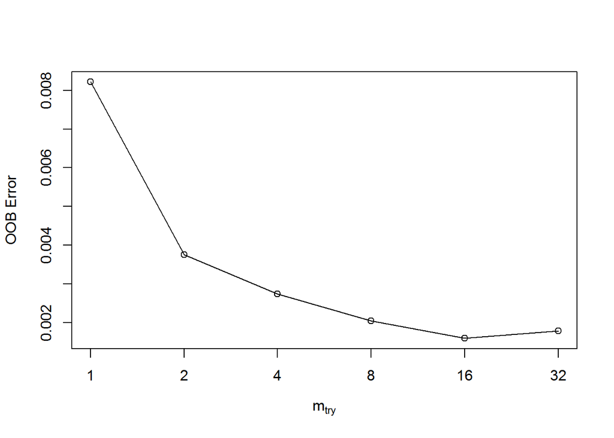

```
##        mtry    OOBError
## 1.OOB     1 0.008217084
## 2.OOB     2 0.003758201
## 4.OOB     4 0.002739028
## 8.OOB     8 0.002038346
## 16.OOB   16 0.001592458
## 32.OOB   32 0.001783553
```

```r
tuneRF(training[,-length(training)], training[,length(training)], mtryStart=2, ntreeTry=500, stepFactor=2, improve=0.005,trace=FALSE, plot=TRUE, doBest=FALSE)
```

#### It shows that the best number of variables is 16.

#### The figure below shows the ranking of variable importance by Mean Decrease Accuracy and Mean Decrease Gini

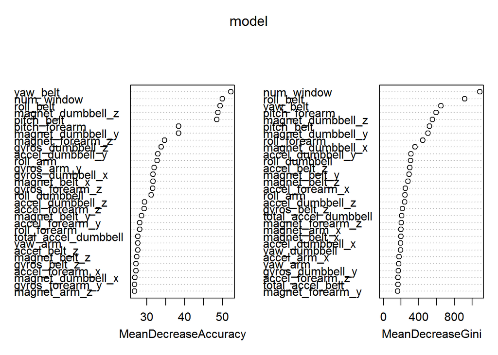

```r
varImpPlot(model)
```

## Investigate “num_window” variable

#### The “num_window” looks suspecious as it maybe a sustitute of surrogate key, in which case should not be included in the training set.

#### From the hitogram of “num_window”, it can be seen that the value is continously distributed and seems being broken into a number of sections corresponding to different class of activities respectively.

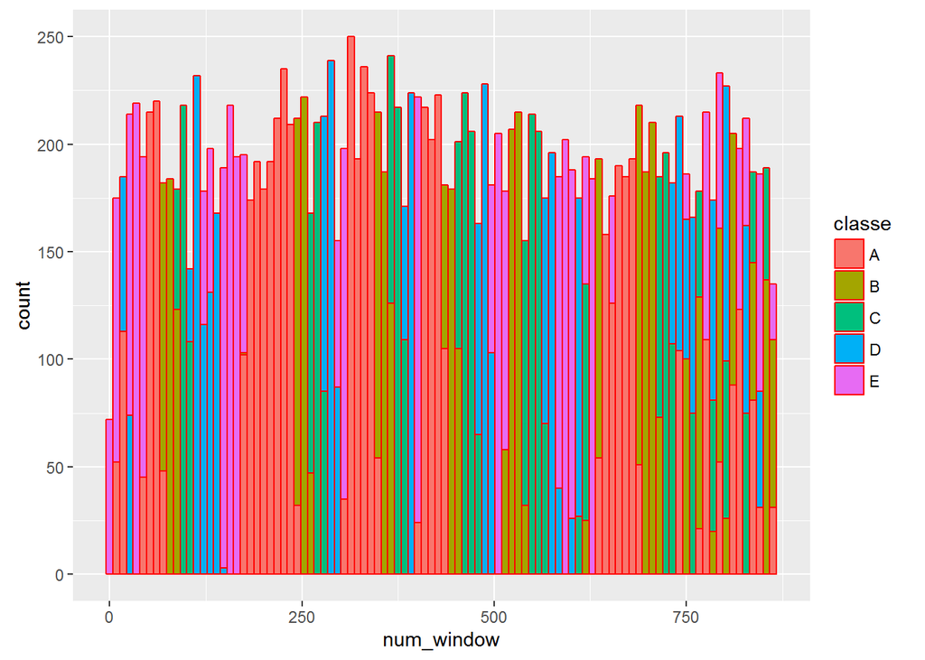

```r
d <- rbind(training,testing)
ggplot(data=d, aes(num_window)) + geom_histogram(col="red",aes(fill=classe),bins=100)
```

```r
set.seed(60515)
model_num_window<- randomForest(classe~.,data=training[,c("num_window","classe")])
model_num_window
```

```
##
## Call:
##  randomForest(formula = classe ~ ., data = training[, c("num_window",      "classe")])
##                Type of random forest: classification
##                      Number of trees: 500
## No. of variables tried at each split: 1
##
##         OOB estimate of  error rate: 0.01%
## Confusion matrix:
##      A    B    C    D    E  class.error
## A 4464    0    0    0    0 0.0000000000
## B    0 3038    0    0    0 0.0000000000
## C    0    0 2738    0    0 0.0000000000
## D    0    0    0 2573    0 0.0000000000
## E    0    0    0    1 2885 0.0003465003
```

```r
pd_num_window <- predict(model_num_window,testing)
acc_num_window <- sum(testing$classe==pd_num_window)/length(testing$classe)
1-acc_num_window
```

```
## [1] 0.000254907
```

## Discard variables which are highly correlated

#### It is recommended that highly correlated variables should be trimed before training, with only one variable left per group. For example, if variable Z is the result of linear function of variable X and Y (Z=aX+bY), than only Z should be retained in the training set.

#### A resonable smaller set of variables can speed up model training. It may have better accuracy on prediction as well.

#### We create a correlation metrix for each variable pairs and discard some of those given a boundary of 0.75 correlation.

```r
#Calculate correlation matrix
correlationMatrix <- cor(training)
# find attributes that are highly corrected (ideally >0.75)
highlyCorrelated <- findCorrelation(correlationMatrix, cutoff=0.75)

unselected<- names(training[,highlyCorrelated])

selected<-names(training[,-highlyCorrelated])
```

[output not shown]

#### Select 33 variables

```r
selected
```

```
##  [1] "yaw_belt"             "gyros_belt_x"         "gyros_belt_y"
##  [4] "gyros_belt_z"         "magnet_belt_x"        "magnet_belt_y"
##  [7] "roll_arm"             "pitch_arm"            "yaw_arm"
## [10] "total_accel_arm"      "gyros_arm_y"          "gyros_arm_z"
## [13] "magnet_arm_x"         "magnet_arm_z"         "roll_dumbbell"
## [16] "pitch_dumbbell"       "yaw_dumbbell"         "total_accel_dumbbell"
## [19] "gyros_dumbbell_y"     "magnet_dumbbell_z"    "roll_forearm"
## [22] "pitch_forearm"        "yaw_forearm"          "total_accel_forearm"
## [25] "gyros_forearm_x"      "gyros_forearm_z"      "accel_forearm_x"
## [28] "accel_forearm_z"      "magnet_forearm_x"     "magnet_forearm_y"
## [31] "magnet_forearm_z"     "new_window"           "classe"
```

#### Discard 21 variables

```r
unselected
```

```
##  [1] "accel_belt_z"      "roll_belt"         "accel_belt_y"
##  [4] "accel_arm_y"       "total_accel_belt"  "accel_dumbbell_z"
##  [7] "accel_belt_x"      "pitch_belt"        "magnet_dumbbell_x"
## [10] "accel_dumbbell_y"  "magnet_dumbbell_y" "accel_arm_x"
## [13] "accel_dumbbell_x"  "accel_arm_z"       "magnet_arm_y"
## [16] "magnet_belt_z"     "accel_forearm_y"   "gyros_forearm_y"
## [19] "gyros_dumbbell_x"  "gyros_dumbbell_z"  "gyros_arm_x"
```

# Find the best model

#### The last part of this report is to compare the performance of random forest models under different settings.

#### The variation of settings includes:

- Number of variables in the training set. Choose between the full set (54 variables) or the subset (33 variables) with highly correlated variables removed.
- Number of variables randomly selected to build the tree. Aka, the “mtry” parameter, which is set to c(4,6,8,16)
- Number of trees to grow, ntree= c(100,200,500,1000)

#### The monitored performance includes:

- The out of bag error rate (OOB)
- Error rate against testing data
- Run time for model training

```r
performance_matrix
```

```
##    num_var ntree mtry         OOB testing_error run_time
## 1       54   100    4 0.007898592   0.005098139     7.86
## 2       54   100    6 0.006911268   0.005098139     8.00
## 3       54   100    8 0.006433531   0.003313790     8.42
## 4       54   100   16 0.006178737   0.004078511     9.48
## 5       54   200    4 0.006051341   0.004843232    15.44
## 6       54   200    6 0.005541754   0.005098139    15.90
## 7       54   200    8 0.004458883   0.003823604    16.00
## 8       54   200   16 0.004713676   0.003313790    18.25
## 9       54   500    4 0.004777374   0.004843232    38.27
## 10      54   500    6 0.004649978   0.004078511    38.86
## 11      54   500    8 0.004012994   0.003823604    39.93
## 12      54   500   16 0.004458883   0.003313790    49.46
## 13      54  1000    4 0.004331486   0.005098139    81.79
## 14      54  1000    6 0.004140391   0.004333418    76.85
```

[output cut: 18 more lines]

# Result

#### The result shows that

- The prediction accuracy is better when using the full set of 54 variables than that of using the subset of 33 variables.
- The out of bag error decreases as the number of trees increases in the model.

#### The best model with lowest OOB is as below

```r
performance_matrix[15,]
```

```
##    num_var ntree mtry         OOB testing_error run_time
## 15      54  1000    8 0.003885598   0.003823604     81.2
```

```r
bestmd
```

```
##
## Call:
##  randomForest(formula = classe ~ ., data = training, mtry = 8,      ntree = 1000)
##                Type of random forest: classification
##                      Number of trees: 1000
## No. of variables tried at each split: 8
##
##         OOB estimate of  error rate: 0.38%
## Confusion matrix:
##      A    B    C    D    E class.error
## A 4461    3    0    0    0 0.000672043
## B    8 3026    4    0    0 0.003949967
## C    0    9 2725    4    0 0.004747991
## D    0    0   26 2546    1 0.010493587
## E    0    0    1    4 2881 0.001732502
```

#### The estimated out of sample error is 0.389%

#### Error rate against testing data

```r
ac
```

```
## [1] 0.003823604
```

#### This result is not as good as the model using only “num_window” as predictor.

#### Although “num_window” is available in the final 20 testing cases, using id-like variable to predict outcome is still a means of cheating : P

#### Over all, all models trained by 54 variables performed closly good in terms of error rate on testing data. So it is reasonable to choose a smaller ntree and mtry number to save some computing time.

# Thanks for viewing! :)